# Untitled

```r
suppressMessages(library(ggplot2))
#library(plotly)
suppressMessages(library(dplyr))
suppressMessages(library(tibble))
suppressMessages(library(readr)) # str_c, str_sub
suppressMessages(library(tidyr))
suppressMessages(library(stringr))
suppressMessages(library(lattice)) # splom
suppressMessages(library(MASS)) # for lm.ridge and boxcox, also fucks up dplyrs select
suppressMessages(library(lsmeans)) # for adjusted means
suppressMessages(library(caret)) # confusionMatrix
suppressMessages(library(ROCR))
library(RODBC)
drv <- odbcDriverConnect('driver={SQL Server};server=THE-ENTERPRISE\\SQLEXPRESS;database=WideWorldImporters;trusted_connection=true')
```

### lets build some features in python

- were actually going to use the inflated table with the extra rows
  - recall there are multiple products per order
- bc were going to try and predict per product insteaed of per order now

### maybe a little concerned about bias?

  - - potentially 2 products in the same order could be confounding wiht each other
    - certainly should look into in the real world
    - the way our features are designed though they only use information from previous to the current day
    - I’d ask Alik
- lets bring the features in from python

```r
#train <- tbl_df(sqlQuery(drv, 'select * from feature_table_train;'))
#setwd('./edu/projects/Alik/MMF/ww1')
wdf <- tbl_df(read.csv('features_from_python.csv')) %>%
  mutate(y = total_rev > 10000,
         item_prop_10g = stockitemid_count_gt_n / stockitemid_len,
         customer_prop_10g = customerid_count_gt_n / customerid_len,
         orderdate = as.character(orderdate))
```

```r
df <- wdf %>% filter(orderdate < '2016-01-01')
hold <- wdf %>% filter(orderdate >= '2016-01-01')
set.seed(4)
trix <- runif(nrow(df)) > .7
train <- df[trix,]
test <- df[-trix,]
```

#### lets see how our new features look

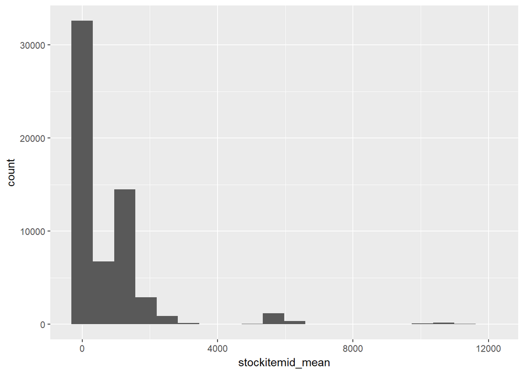

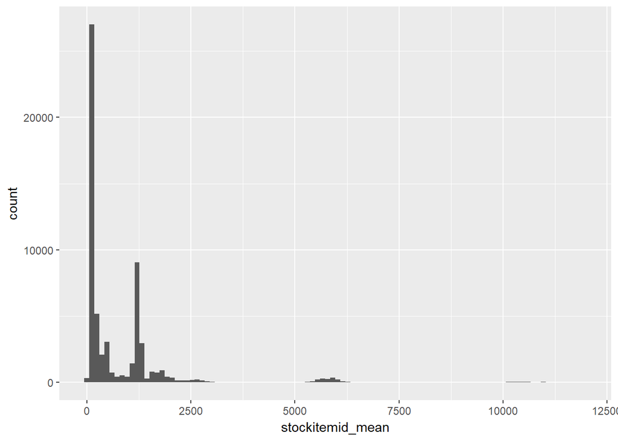

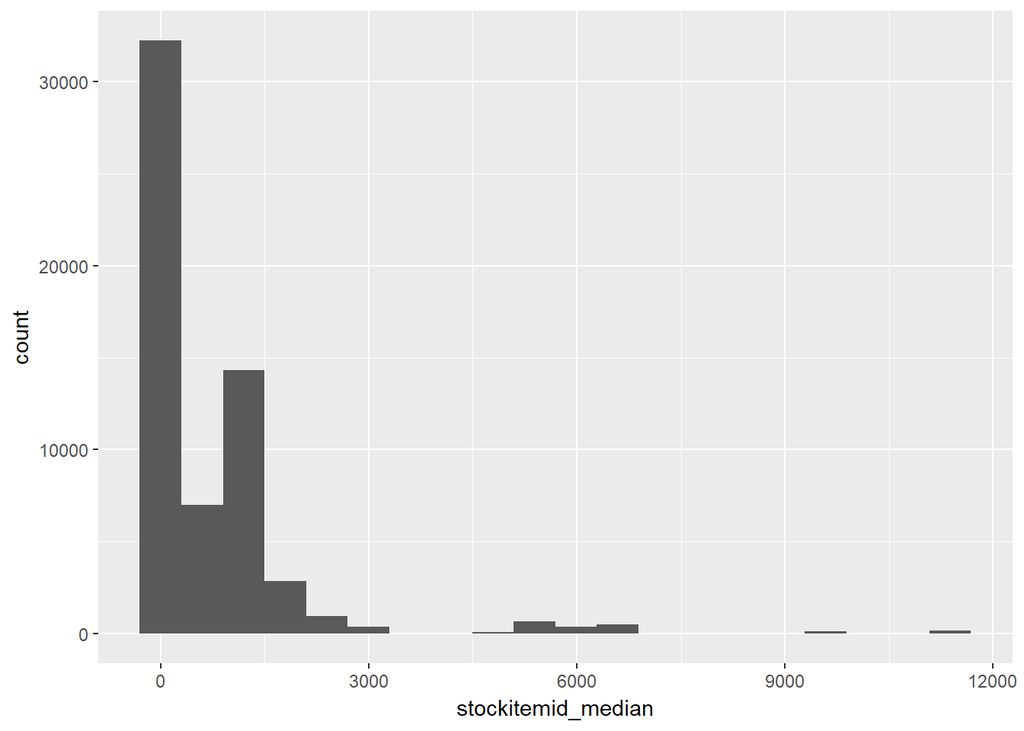

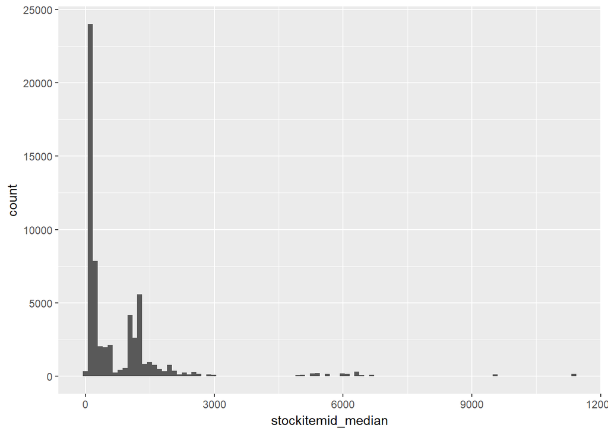

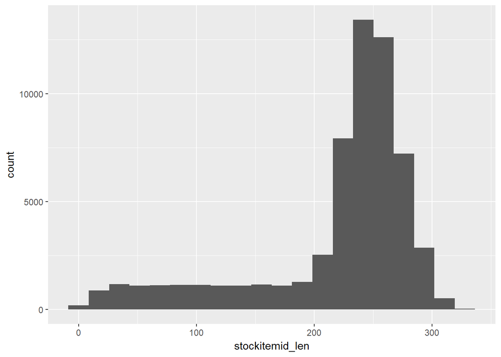

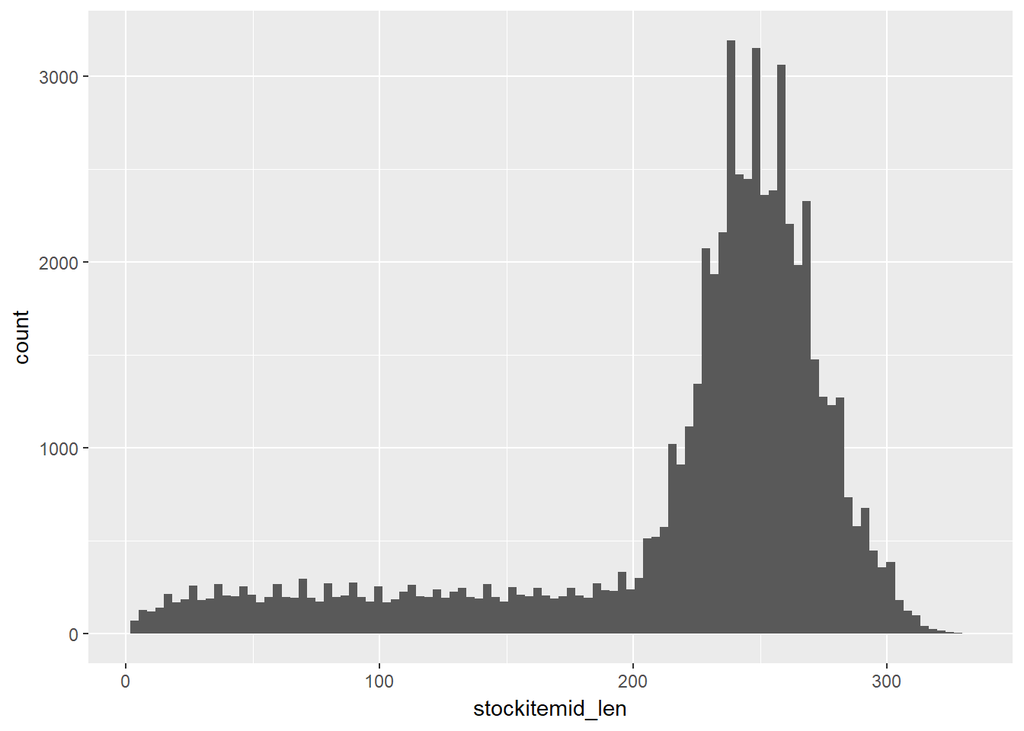

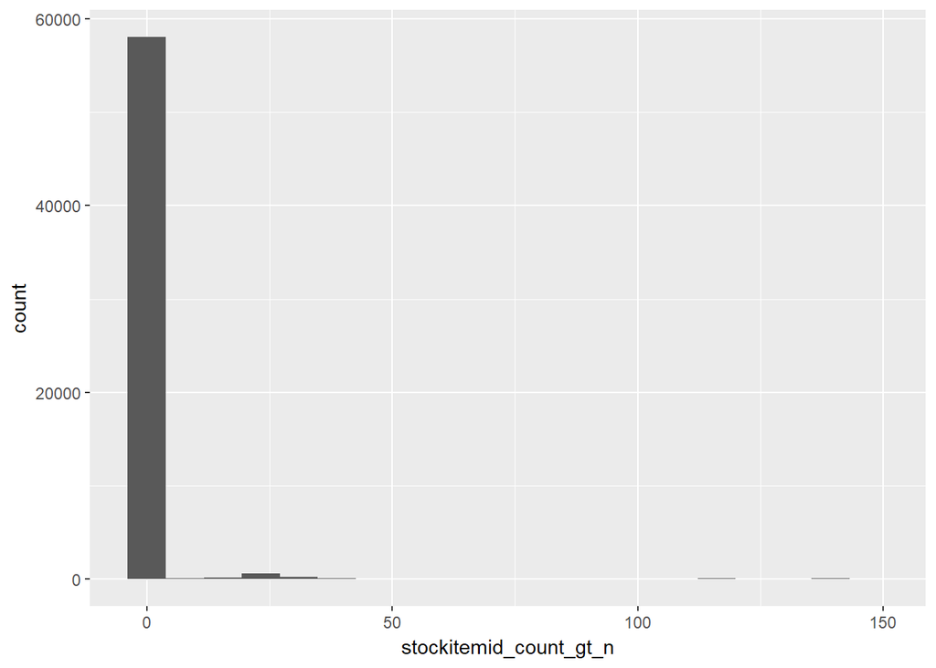

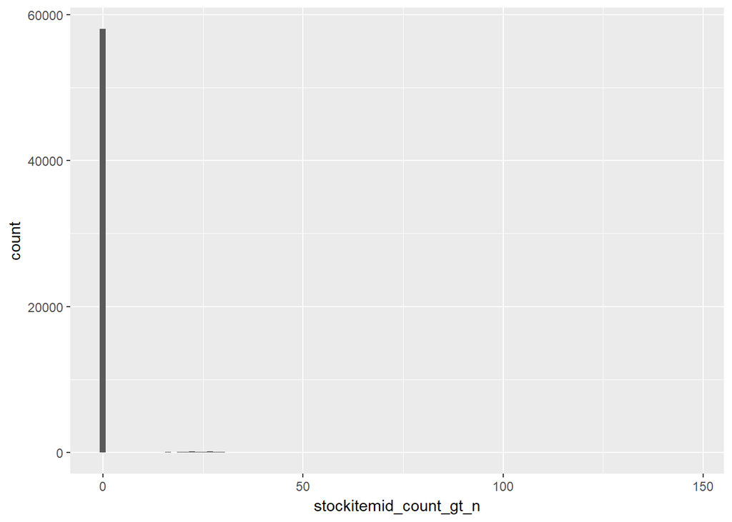

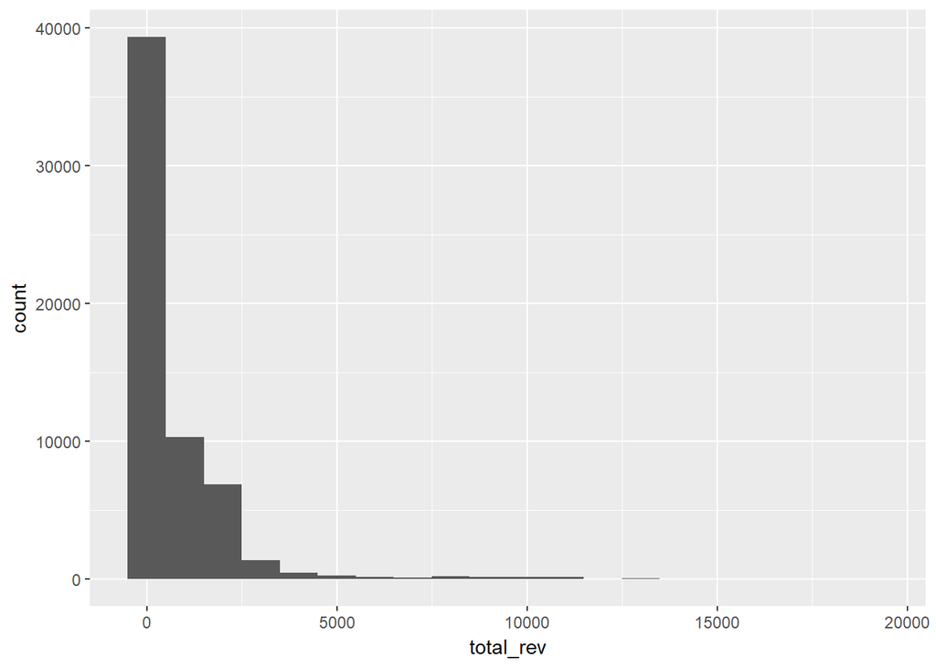

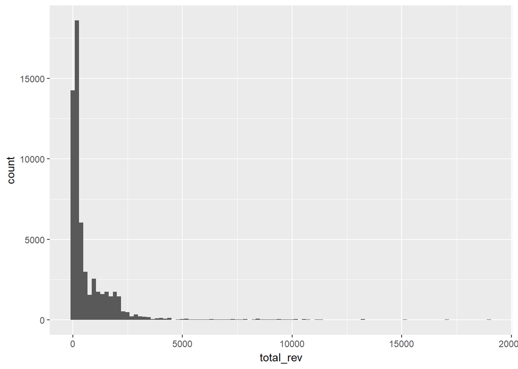

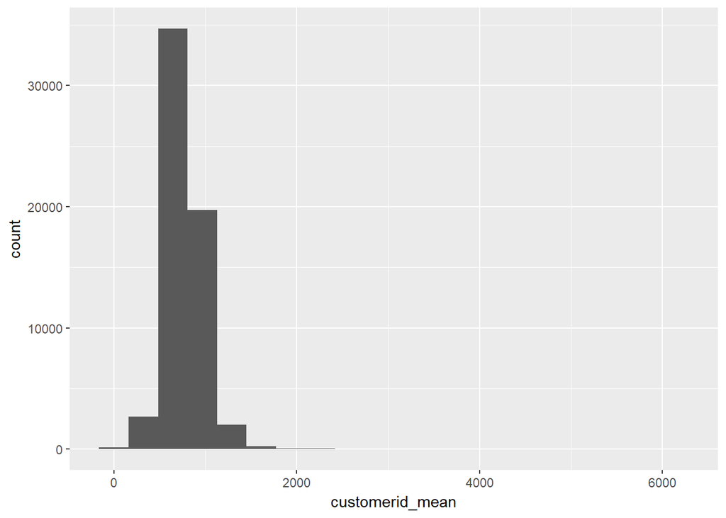

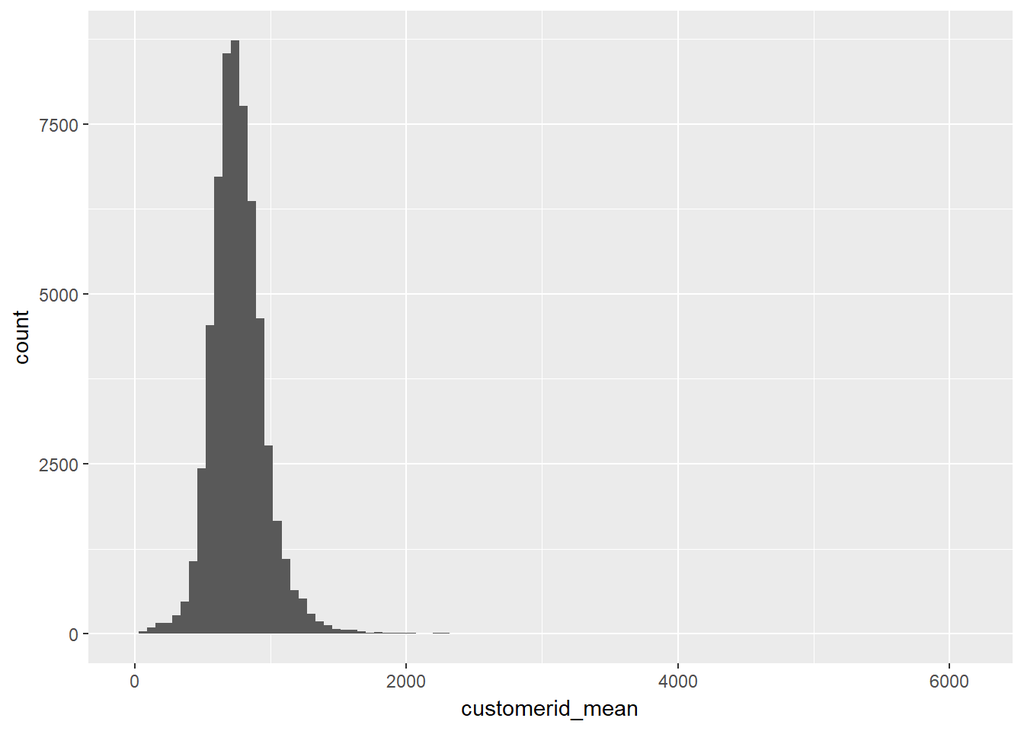

[6 more figures not shown]

```r
feats <- c('stockitemid_mean', 'stockitemid_median',
       'stockitemid_len', 'stockitemid_count_gt_n', 'total_rev',
       'customerid_mean', 'customerid_median', 'customerid_len',
       'customerid_count_gt_n'
       )

for (c in feats) {
  print(
    ggplot(train, aes_string(c)) +
      geom_histogram(bins=20)
  )

  print(
    ggplot(train, aes_string(c)) +
      geom_histogram(bins=100)
  )
}
```

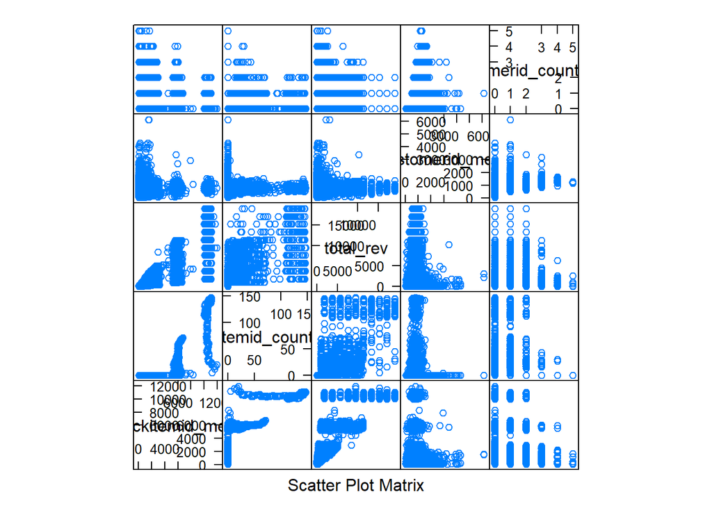

```r
splom_feats <- c('stockitemid_mean', 'stockitemid_count_gt_n', 'total_rev',
       'customerid_mean',
       'customerid_count_gt_n'
       )
splom(train[splom_feats])
```

- mean and median both look to have some high roller groups (probably the same) - looks to be some signal in the splom! - some of these are very peaky - likely because of the way the data was generated, or maybe because people usually make orders of 2 items at once?

#### 10000 looks to be too far out now?

- good job we QAd

```r
summarise(train, sum(y) / nrow(train))
```

```
## # A tibble: 1 x 1
##   `sum(y)/nrow(train)`
##                  <dbl>
## 1          0.005346339
```

```r
summarise(train, sum(total_rev > 5000) / nrow(train))
```

```
## # A tibble: 1 x 1
##   `sum(total_rev > 5000)/nrow(train)`
##                                 <dbl>
## 1                          0.01975967
```

- thats bc the 10g was based on the entire order not per product
- fortunately our code is super modular so to fix our feature we just need to change a number and press entire
- for the sake of time (our code is slow) lets adjust our dependent to > 5g and run with the features we have

### change our dep (thank god for QA, its a life saver)

```r
train$y <- train$total_rev > 5000
test$y <- test$total_rev > 5000
hold$y <- hold$total_rev > 5000
```

#### lets identify some filtering

- based on the distributions above we’ve got some left skew/light right tail on our counts, mostly concentrated around > 200

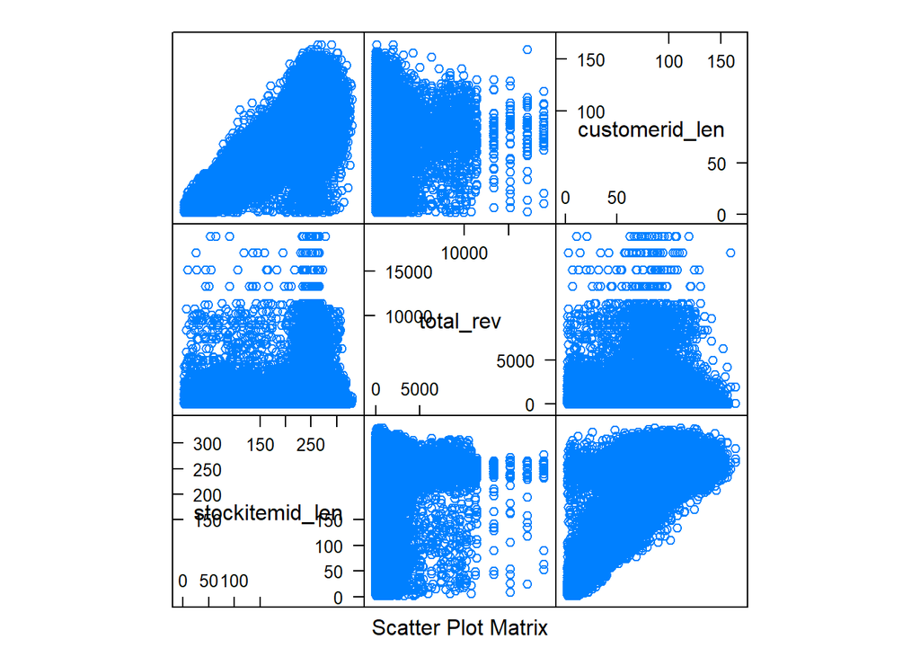

```r
filt_feats <- c('stockitemid_len', 'total_rev',
       'customerid_len')

splom(train[filt_feats])
```

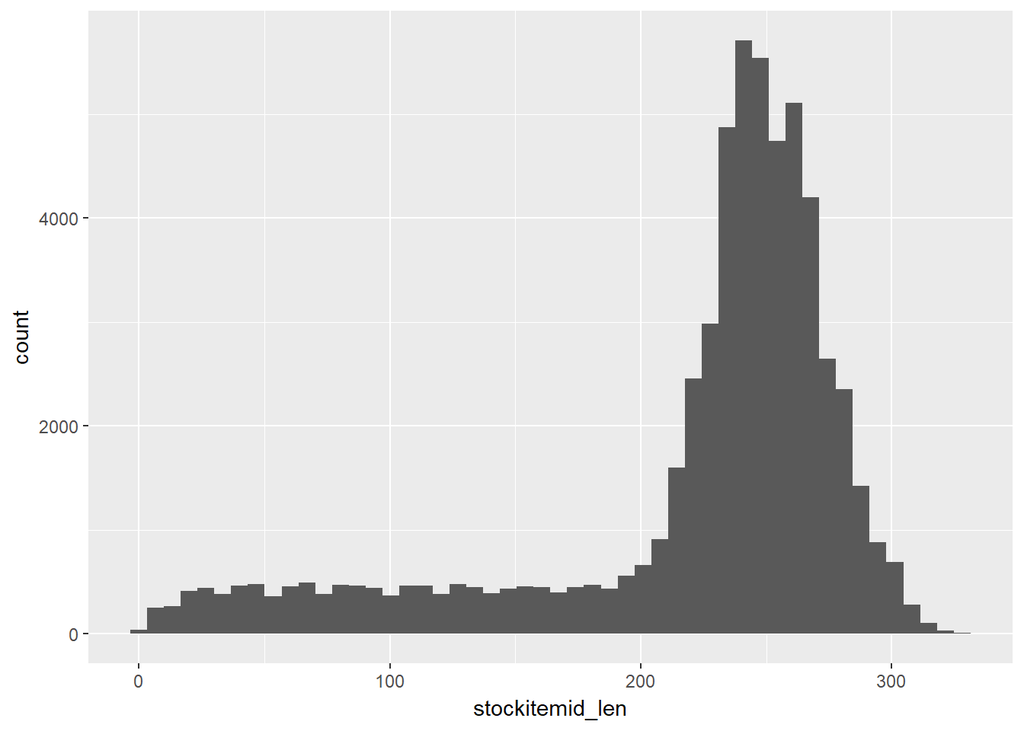

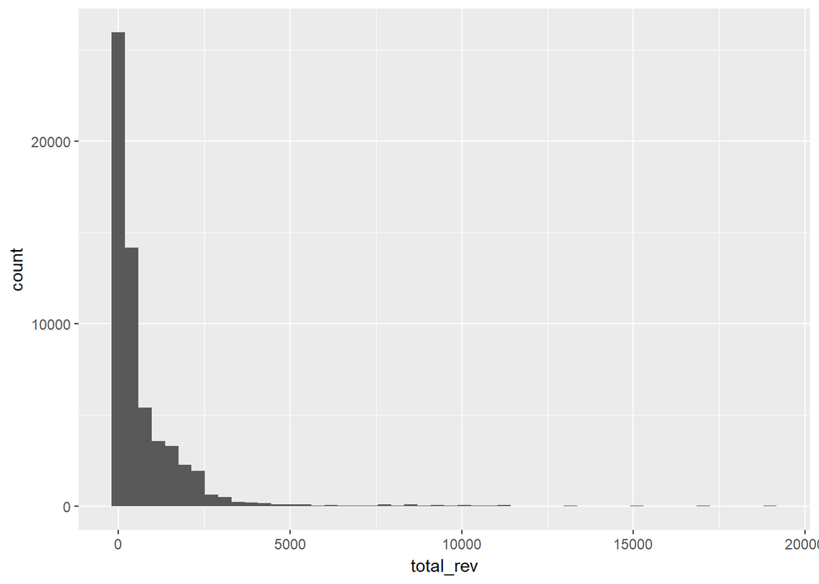

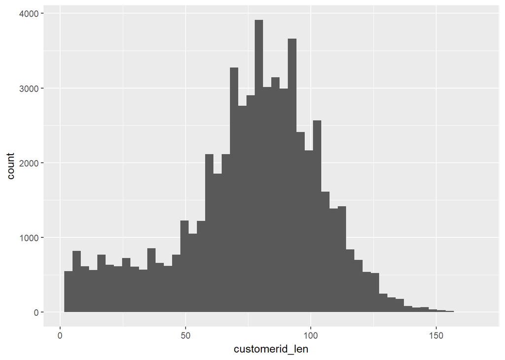

```r
for (c in filt_feats) {
  print(
    ggplot(train, aes_string(c)) +
      geom_histogram(bins=50)
  )
}
```

- notice we can see the univariate distributions present in our splom!
- doesnt look to be an obvious point from the splom! so lets just use the histograms
  - often you’ll see some serious regression towards the mean, and its a good idea to pick something in a more stable area
- **Note: using a std from the mean for the number of transactions used to derive a feature for each product (stockitemid_len) as a filtering method wouldnt be very effective, bc it doesnt accurately represent what we want**
- lets use 50 and 200 and focus on the concentration of the data

```r
trainf <- train %>% filter(stockitemid_len > 200, customerid_len > 50)
testf <- test %>% filter(stockitemid_len > 200, customerid_len > 50)
holdf <- hold %>% filter(stockitemid_len > 200, customerid_len > 50)

dim(train)
```

```
## [1] 59667    17
```

```r
dim(trainf)
```

```
## [1] 45517    17
```

nice

### Optimal binning

- **Note: important to make sure that any feature engineering you do base don the dependent variable is done solely on the training set, and then said features are applied to the testing**
  - ex mean(dependent per) per bin of the independent
  - if you derive this on the testing you’ll be cheating and you model wont generalize

```r
library(smbinning)
```

```r
opt_bin <- function(train, test, hold, feats, dep='y', p=.1) {
  # compute optimal bins for each feature and add new cols into train and test
  # NOTE: important not to do this on the whole dataframe
  # p = proportion of

  #tr <- train[,] # dont change a variable inside a function copy it
  tr <- data.frame(train[,]) # dont change a variable inside a function copy it
  #print(str_c('max of tr$y: ', max(tr$y)))
  tr$y <- tr$y*1
  #print(str_c('max of tr$y: ', max(tr$y)))
  te <- data.frame(test[,])
  h <- data.frame(hold[,])
  for (f in feats) {
    print(str_c('max of tr$y (should == 1, if not probably empty): ', max(tr$y)))
    smb <- smbinning(df=tr, y=dep, x=f, p=p)
    if (!is.character(smb)) {
      try(smbinning.plot(smb, option='WoE', sub=f))
      tr <- smbinning.gen(tr, smb, chrname=str_c(f, '_opt_bin'))
      te <- smbinning.gen(te, smb, chrname=str_c(f, '_opt_bin'))
      h <- smbinning.gen(te, smb, chrname=str_c(f, '_opt_bin'))
    }
    else {
      print(smb)
    }
  }

  return(list(train=tr, test=te, hold=h))
}

feats <- c('stockitemid_mean', 'stockitemid_median',
       'stockitemid_len', 'stockitemid_count_gt_n',
       'customerid_mean', 'customerid_median', 'customerid_len',
       'customerid_count_gt_n'
       )


opts <- opt_bin(trainf, testf, hold, feats)
```

```
## [1] "max of tr$y (should == 1, if not probably empty): 1"
```

```
## [1] "max of tr$y (should == 1, if not probably empty): 1"
```

```
## [1] "max of tr$y (should == 1, if not probably empty): 1"
```

```
## [1] "max of tr$y (should == 1, if not probably empty): 1"
## [1] "No significant splits"
## [1] "max of tr$y (should == 1, if not probably empty): 1"
## [1] "No significant splits"
## [1] "max of tr$y (should == 1, if not probably empty): 1"
## [1] "No significant splits"
## [1] "max of tr$y (should == 1, if not probably empty): 1"
## [1] "No significant splits"
## [1] "max of tr$y (should == 1, if not probably empty): 1"
## [1] "No significant splits"
```

```r
trf <- opts$train
tef <- opts$test
hd <- opts$hold
```

- fyi: “Target (y) not found or it is not numeric” will print often from smb
  - could be bc its not numeriv
  - often for me its because the data sets are tibbles not data.frames
  - btw: R errors often suck like this

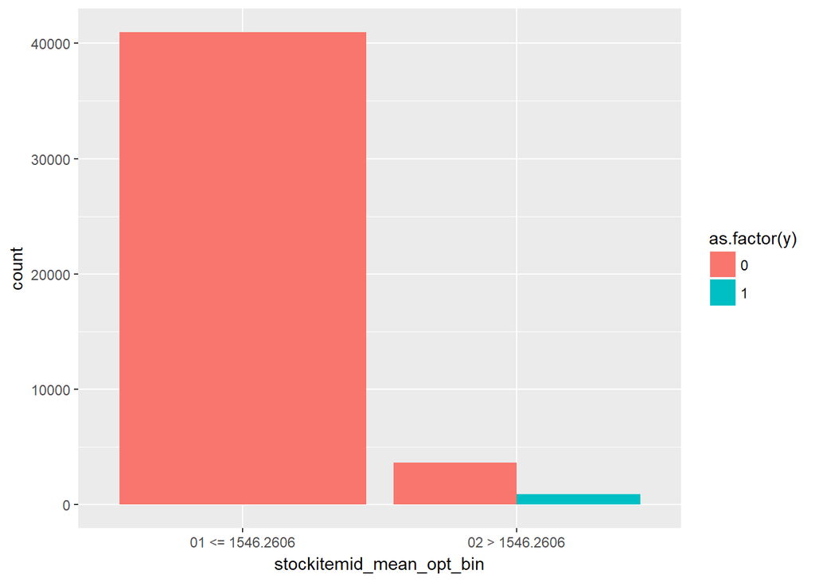

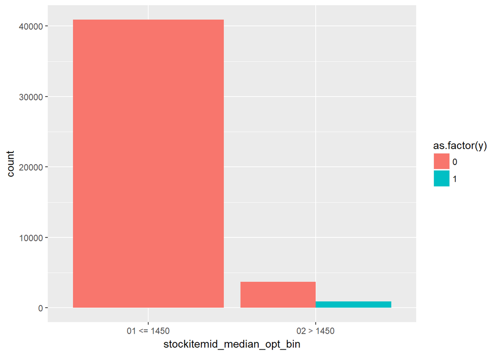

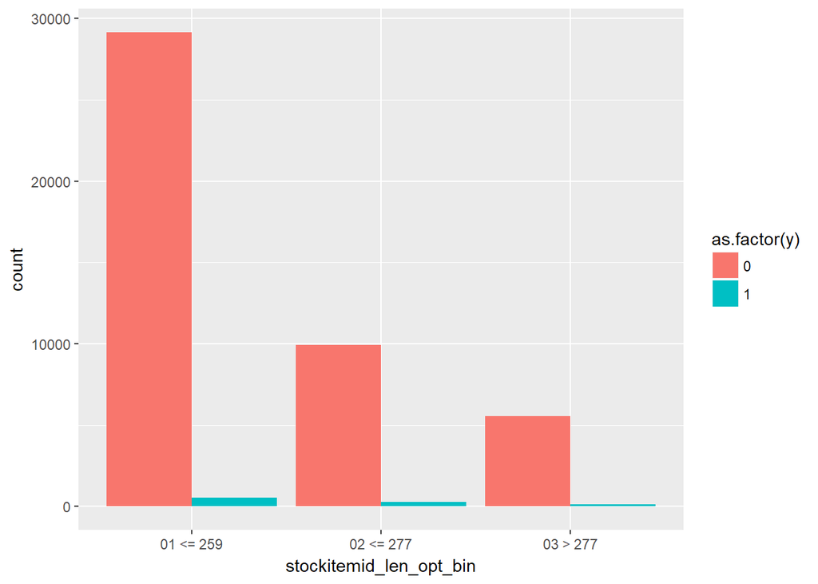

```r
opt_bins <- names(trf %>% dplyr::select(ends_with('opt_bin')))

for (o in opt_bins) {
  print(
    ggplot(trf, aes_string(o, fill='as.factor(y)')) +
      geom_bar(position='dodge')
  )
}
```

### lets try a reduced cut

```r
trainf$y <- trainf$total_rev > 2500
testf$y <- testf$total_rev > 2500
holdf$y <- holdf$total_rev > 2500

opts <- opt_bin(trainf, testf, hold, feats)
```

```
## [1] "max of tr$y (should == 1, if not probably empty): 1"
```

```
## [1] "max of tr$y (should == 1, if not probably empty): 1"
```

```
## [1] "max of tr$y (should == 1, if not probably empty): 1"
## [1] "No significant splits"
## [1] "max of tr$y (should == 1, if not probably empty): 1"
## [1] "No significant splits"
## [1] "max of tr$y (should == 1, if not probably empty): 1"
## [1] "No significant splits"
## [1] "max of tr$y (should == 1, if not probably empty): 1"
## [1] "No significant splits"
## [1] "max of tr$y (should == 1, if not probably empty): 1"
## [1] "No significant splits"
## [1] "max of tr$y (should == 1, if not probably empty): 1"
## [1] "No significant splits"
```

```r
trf <- opts$train
tef <- opts$test
hd <- opts$hold

opt_bins <- names(trf %>% dplyr::select(ends_with('opt_bin')))

for (o in opt_bins) {
  print(
    ggplot(trf, aes_string(o, fill='as.factor(y)')) +
      geom_bar(position='dodge')
  )
}
```

[output not shown]

- actually pretty good
- we can catch every label in the upper 2 bins of the features

## *sighs in relief* now for the easy part model selection and tuning

### logistic regression on new featuers

```r
glm1 <- glm(y ~ ., data=trf[append('y', opt_bins)], family='binomial')
anova(glm1, test='LRT')
```

```
## Analysis of Deviance Table
##
## Model: binomial, link: logit
##
## Response: y
##
## Terms added sequentially (first to last)
##
##
##                            Df Deviance Resid. Df Resid. Dev
## NULL                                       45516    18424.2
## stockitemid_mean_opt_bin    2    11503     45514     6920.8
## stockitemid_median_opt_bin  2      143     45512     6777.9
##                                         Pr(>Chi)
## NULL
## stockitemid_mean_opt_bin   < 0.00000000000000022 ***
## stockitemid_median_opt_bin < 0.00000000000000022 ***
## ---
## Signif. codes:  0 '***' 0.001 '**' 0.01 '*' 0.05 '.' 0.1 ' ' 1
```

```r
summary(glm1)
```

```
##
## Call:
## glm(formula = y ~ ., family = "binomial", data = trf[append("y",
##     opt_bins)])
##
## Deviance Residuals:
##    Min      1Q  Median      3Q     Max
## -1.195   0.000   0.000   0.000   2.949
##
## Coefficients:
##                                         Estimate Std. Error z value
## (Intercept)                               -34.30     304.91  -0.112
## stockitemid_mean_opt_bin02 <= 1533.5773    15.19     215.20   0.071
## stockitemid_mean_opt_bin03 > 1533.5773     18.02     215.20   0.084
## stockitemid_median_opt_bin02 <= 1450       14.77     216.00   0.068
## stockitemid_median_opt_bin03 > 1450        16.32     216.00   0.076
##                                         Pr(>|z|)
## (Intercept)                                0.910
## stockitemid_mean_opt_bin02 <= 1533.5773    0.944
## stockitemid_mean_opt_bin03 > 1533.5773     0.933
## stockitemid_median_opt_bin02 <= 1450       0.945
## stockitemid_median_opt_bin03 > 1450        0.940
##
## (Dispersion parameter for binomial family taken to be 1)
##
##     Null deviance: 18424.2  on 45516  degrees of freedom
## Residual deviance:  6777.9  on 45512  degrees of freedom
## AIC: 6787.9
##
## Number of Fisher Scoring iterations: 21
```

### lets eval

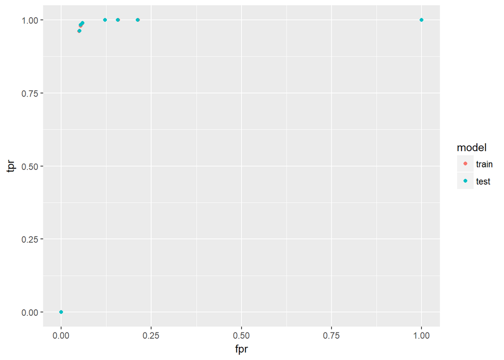

```r
roc_glm_df <- function(train, test, glm) {
  trprobs <- predict(glm, newdata=train, type='response')
  trperf <- performance(prediction(trprobs, train$y),
                        measure='tpr', x.measure='fpr')
  teprobs <- predict(glm, newdata=test, type='response')
  teperf <- performance(prediction(teprobs, test$y),
                        measure='tpr', x.measure='fpr')
  rocdf <- rbind(
    data.frame(fpr = unlist(trperf@x.values),
               tpr = unlist(trperf@y.values),
               model='train'),
    data.frame(fpr = unlist(teperf@x.values),
               tpr = unlist(teperf@y.values),
               model='test')
  )
  return (rocdf)
}

rocdf <- roc_glm_df(trf, tef, glm1)
ggplot(rocdf, aes(fpr, tpr, color=model)) +
  geom_point()
```

#### lets try on the holdout

[figure not shown]

```r
rocdf <- roc_glm_df(trf, hd, glm1)
ggplot(rocdf, aes(fpr, tpr, color=model)) +
  geom_point()
```

### this is alarmingly good though?

- its because of our feature bins, notice the upper bins have 100% of the labels
- and even though the percentage of labels to not is around 50% this corresponds to a very small % of all the negative labels, leading to a very small FPR.

#### quick double check to see how these bins look in our testing and validation

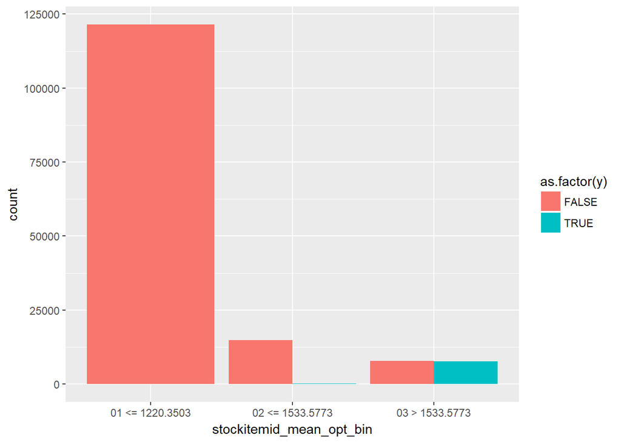

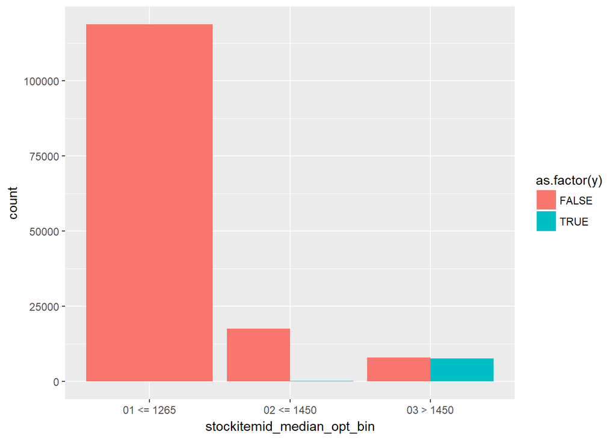

```r
for (o in opt_bins) {
  print(
    ggplot(tef, aes_string(o, fill='as.factor(y)')) +
      geom_bar(position='dodge')
  )
}
```

features are very strong in the testing too

## lets also see that there’s uniqueness betwen the two

- we should have unique orderlineIDs
- **potential source of bias is the sam orderID across both testing and training, although this would bias the customers not the products**

```r
#dim(trf %>% inner_join(tef, by='orderid'))
dim(trf %>% inner_join(tef, by='orderlineid'))
```

```
## [1] 45625    37
```

# Bias, we didnt QA enough obviously, good job we checked

```r
dim(train)
```

```
## [1] 59667    17
```

```r
dim(test)
```

```
## [1] 199254     17
```

```r
dim(testf)
```

```
## [1] 152036     17
```

```r
dim(trainf)
```

```
## [1] 45517    17
```

bc here is how we defined our training and testing (backwards)

```r
# trix <- runif(nrow(df)) > .7
# train <- df[trix,]
# test <- df[-trix,]
```

this doesnt explain the overlap in the primary key though

```r
nrow(df %>% dplyr::select(orderlineid) %>% distinct())
```

```
## [1] 199076
```

```r
nrow(df)
```

```
## [1] 199255
```

### should have checked that our primary key was unique after finishing the feature engineering

- heres another problem we have to deal with
- **also shouldnt have used inner joins but left joins in our feature engineering**

## ‘#NoMoreInnerJoins’

  - we validated the feature engineering at the end by checking the dimension of features < dimension of the raw data and it was close to the same size which looked pretty good
  - as we can see above this was not a reliable measure
  - had we have been using left joins the number of rows would have been bigger in the features

### lets double check the problem doesnt go back further

```r
prod_info <- sqlQuery(drv, 'select * from Sales.OrderLines')
dim(prod_info %>% dplyr::select(OrderLineID) %>% distinct())
```

```
## [1] 231412      1
```

```r
dim(prod_info)
```

```
## [1] 231412     12
```

```r
orig_feats <- sqlQuery(drv, 'select * from feature_table_per_order')
dim(orig_feats %>% dplyr::select(OrderLineID) %>% distinct())
```

```
## [1] 231412      1
```

```r
dim(orig_feats)
```

```
## [1] 231412     27
```

- so it looks like the bug is in our feature engineering
  - likely in one of our joins
  - **in our QA we should have checked for unique primary key after every join we made not only dimensions**
  - **especially in the output**
  - after doing so it should be easy to identify the problem

## Still does not explain why we have so much overlap in our training and testing

- after doing our initial split we should have validated that there was no overlap

recall here was our code:

```r
trix <- runif(nrow(df)) > .7
train <- df[trix,]
test <- df[-trix,]

dim(test)
```

```
## [1] 199254     17
```

```r
dim(df)
```

```
## [1] 199255     17
```

```r
# what actually wanted was:
trix <- runif(nrow(df)) < .7
train <- df[trix,]
test <- df[!trix,]
dim(train)
```

```
## [1] 139591     17
```

```r
dim(test)
```

```
## [1] 59664    17
```

## More Analysis below to and identify significant customer based features from before discovering our bug above

- it didn’t work anyways so were not too concerned above it being affected
- next steps would be:
  - find the bug in feature eng
  - double check our result above still holds
  - try to come up with for more features to leverage customer history

#### lets investigiate a little more still (we’ll look in the validation set)

what are these killer items?

```r
library(RODBC)
#db <- odbcDriverConnect('driver={SQL Server};server=localhost;database=WideWorldImporters;trusted_connection=true')
drv <- odbcDriverConnect('driver={SQL Server};server=THE-ENTERPRISE\\SQLEXPRESS;database=WideWorldImporters;trusted_connection=true')

prod_info <- sqlQuery(drv, 'select * from Sales.OrderLines')

top_prods <- tbl_df(tef %>% filter(stockitemid_median_opt_bin == '03 > 1450',
                            stockitemid_mean_opt_bin == '03 > 1533.5773') %>%
  inner_join(prod_info, by=c('orderlineid' = 'OrderLineID')))

dim(top_prods)
```

```
## [1] 14840    30
```

```r
top_prods
```

```
## # A tibble: 14,840 x 30
##        X customerid customerid_mean customerid_median customerid_len
##    <int>      <int>           <dbl>             <dbl>          <dbl>
##  1     4         11        913.5400            216.00             95
##  2    15        127        858.3828            246.75             58
##  3    31        192       1221.9708            280.00             53
##  4    42        200        513.6219            240.00             73
##  5    49        415        962.5427            300.00            103
##  6    52        419        490.4965            224.00             99
##  7    55        442        783.9448            240.00             87
##  8    65        453        923.1098            240.00             56
##  9    75        534        717.3939            256.00             57
## 10    76        534        717.3939            256.00             57
## # ... with 14,830 more rows, and 25 more variables:
## #   customerid_count_gt_n <dbl>, stockitemid <int>, total_rev <dbl>,
## #   orderdate <chr>, orderlineid <int>, stockitemid_mean <dbl>,
## #   stockitemid_median <dbl>, stockitemid_len <dbl>,
## #   stockitemid_count_gt_n <dbl>, y <lgl>, item_prop_10g <dbl>,
## #   customer_prop_10g <dbl>, stockitemid_mean_opt_bin <fctr>,
## #   stockitemid_median_opt_bin <fctr>, OrderID <int>, StockItemID <int>,
## #   Description <fctr>, PackageTypeID <int>, Quantity <int>,
## #   UnitPrice <dbl>, TaxRate <dbl>, PickedQuantity <int>,
## #   PickingCompletedWhen <fctr>, LastEditedBy <int>, LastEditedWhen <fctr>
```

mean that much higher than the median suggests outliers

```r
top_prods %>% dplyr::select(Description, stockitemid_mean) %>% arrange(-stockitemid_mean)
```

```
## # A tibble: 14,840 x 2
##                   Description stockitemid_mean
##                        <fctr>            <dbl>
##  1 Air cushion machine (Blue)         11105.82
##  2 Air cushion machine (Blue)         11105.82
##  3 Air cushion machine (Blue)         11102.42
##  4 Air cushion machine (Blue)         11102.42
##  5 Air cushion machine (Blue)         11102.42
##  6 Air cushion machine (Blue)         11100.11
##  7 Air cushion machine (Blue)         11100.11
##  8 Air cushion machine (Blue)         11099.08
##  9 Air cushion machine (Blue)         11099.08
## 10 Air cushion machine (Blue)         11099.08
## # ... with 14,830 more rows
```

```r
# one badass blue air cushion machine
top_prods %>% arrange(-stockitemid_mean) %>%
  dplyr::select(Description) %>% distinct()
```

```
## # A tibble: 24 x 1
##                                 Description
##                                      <fctr>
##  1               Air cushion machine (Blue)
##  2       32 mm Double sided bubble wrap 50m
##  3       20 mm Double sided bubble wrap 50m
##  4 32 mm Anti static bubble wrap (Blue) 50m
##  5       10 mm Double sided bubble wrap 50m
##  6 10 mm Anti static bubble wrap (Blue) 50m
##  7 20 mm Anti static bubble wrap (Blue) 50m
##  8 32 mm Anti static bubble wrap (Blue) 20m
##  9         Void fill 400 L bag (White) 400L
## 10 20 mm Anti static bubble wrap (Blue) 20m
## # ... with 14 more rows
```

## lets fix our features and see if we can more signal from the customer features

- we should have added counts gt w multiple levels to start with

```r
wdf <- tbl_df(read.csv('features_from_python_gs.csv')) %>%
  mutate(y = total_rev > 10000,
         orderdate = as.character(orderdate))

for (g in c('1g', '25g', '5g')) { # should have done these in python
  wdf[str_c('item_prop_',g)] = wdf[str_c('stockitemid_count_gt_',g)] / wdf$stockitemid_len
  wdf[str_c('customer_prop_',g)] = wdf[str_c('customerid_count_gt_',g)] / wdf$customerid_len
}

df <- wdf %>% filter(orderdate < '2016-01-01')
hold <- wdf %>% filter(orderdate >= '2016-01-01')
set.seed(4)
trix <- runif(nrow(df)) > .7
train <- df[trix,]
test <- df[-trix,]

trainf <- train %>% filter(stockitemid_len > 200, customerid_len > 50)
testf <- test %>% filter(stockitemid_len > 200, customerid_len > 50)
holdf <- hold %>% filter(stockitemid_len > 200, customerid_len > 50)

trainf$y <- trainf$total_rev > 2500
testf$y <- testf$total_rev > 2500
holdf$y <- holdf$total_rev > 2500
```

```r
feats <- names(train %>%
                 dplyr::select(ends_with('g'), ends_with('len'),
                               ends_with('mean'), ends_with('median')))


opts <- opt_bin(trainf, testf, hold, feats)
```

```
## [1] "max of tr$y (should == 1, if not probably empty): 1"
## [1] "No significant splits"
## [1] "max of tr$y (should == 1, if not probably empty): 1"
## [1] "No significant splits"
## [1] "max of tr$y (should == 1, if not probably empty): 1"
## [1] "No significant splits"
## [1] "max of tr$y (should == 1, if not probably empty): 1"
```

```
## [1] "max of tr$y (should == 1, if not probably empty): 1"
```

```
## [1] "max of tr$y (should == 1, if not probably empty): 1"
## [1] "No significant splits"
## [1] "max of tr$y (should == 1, if not probably empty): 1"
```

```
## [1] "max of tr$y (should == 1, if not probably empty): 1"
## [1] "No significant splits"
## [1] "max of tr$y (should == 1, if not probably empty): 1"
```

```
## [1] "max of tr$y (should == 1, if not probably empty): 1"
## [1] "No significant splits"
## [1] "max of tr$y (should == 1, if not probably empty): 1"
## [1] "No significant splits"
## [1] "max of tr$y (should == 1, if not probably empty): 1"
## [1] "No significant splits"
## [1] "max of tr$y (should == 1, if not probably empty): 1"
## [1] "No significant splits"
## [1] "max of tr$y (should == 1, if not probably empty): 1"
```

```
## [1] "max of tr$y (should == 1, if not probably empty): 1"
## [1] "No significant splits"
## [1] "max of tr$y (should == 1, if not probably empty): 1"
```

```
## [1] "max of tr$y (should == 1, if not probably empty): 1"
## [1] "No significant splits"
## [1] "max of tr$y (should == 1, if not probably empty): 1"
```

```r
trf <- opts$train
tef <- opts$test
hd <- opts$hold

opt_bins <- names(trf %>% dplyr::select(ends_with('opt_bin')))

for (o in opt_bins) {
  print(
    ggplot(trf, aes_string(o, fill='as.factor(y)')) +
      geom_bar(position='dodge')
  )
}
```

[output not shown]

still dont have any strong featuers for customers though, more stuff to try - try stages in customer life cylcle feature - momentum features - try different varying time intervals to get more recent information

#### lets look into our customer features more

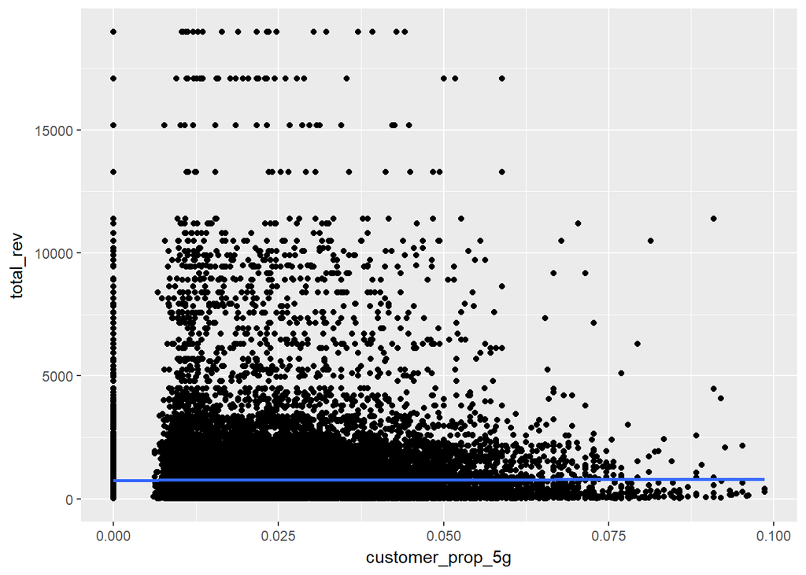

```r
ggplot(trf, aes(customer_prop_5g, total_rev)) +
  geom_point() +
  geom_smooth()
```

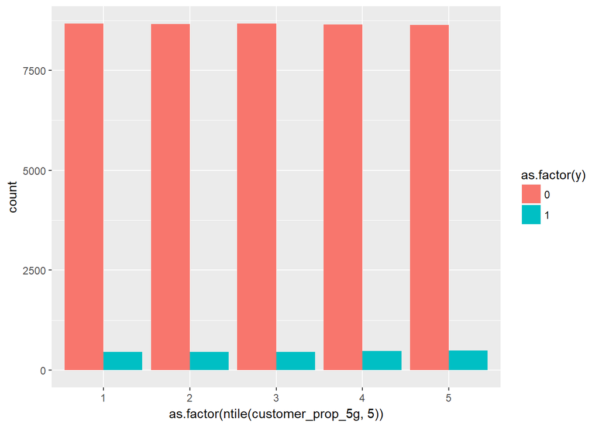

```r
ggplot(trf, aes(as.factor(ntile(customer_prop_5g, 5)), fill=as.factor(y))) +
  geom_bar(position='dodge')
```

- looks like we need more info about an indivual to make their features worthwhile
- we know from the EDA that we have a fairly distinnct number of customers who will make orders of this magnitude the problem is that they usually dont, even the best individually peak at around 10% of their orders
- then next step could be to see what does this
  - potentially if we do an interaction with products?

quick rough check:

```r
glm2 <- glm(y ~ . + customer_prop_25g * item_prop_25g, data=trf[append(feats, 'y')],
            family='binomial')
anova(glm2, test='LRT')
```

```
## Analysis of Deviance Table
##
## Model: binomial, link: logit
##
## Response: y
##
## Terms added sequentially (first to last)
##
##
##                                 Df Deviance Resid. Df Resid. Dev
## NULL                                            45613    18457.7
## customerid_count_gt_1g           1      0.0     45612    18457.7
## customerid_count_gt_25g          1      0.1     45611    18457.6
## customerid_count_gt_5g           1      2.9     45610    18454.8
## stockitemid_count_gt_1g          1  10802.6     45609     7652.2
## stockitemid_count_gt_25g         1   1005.8     45608     6646.4
## stockitemid_count_gt_5g          1    374.0     45607     6272.3
## item_prop_1g                     1    278.8     45606     5993.5
## customer_prop_1g                 1      0.9     45605     5992.6
## item_prop_25g                    1      2.4     45604     5990.1
## customer_prop_25g                1      0.3     45603     5989.8
## item_prop_5g                     1      1.5     45602     5988.3
## customer_prop_5g                 1      1.4     45601     5986.9
## customerid_len                   1      0.2     45600     5986.8
## stockitemid_len                  1      0.1     45599     5986.7
## customerid_mean                  1      0.0     45598     5986.6
## stockitemid_mean                 1      1.7     45597     5984.9
## customerid_median                1      0.3     45596     5984.6
## stockitemid_median               1      4.1     45595     5980.5
## item_prop_25g:customer_prop_25g  1      0.9     45594     5979.6
##                                             Pr(>Chi)
## NULL
## customerid_count_gt_1g                       0.82844
## customerid_count_gt_25g                      0.75931
## customerid_count_gt_5g                       0.09110 .
## stockitemid_count_gt_1g         < 0.0000000000000002 ***
## stockitemid_count_gt_25g        < 0.0000000000000002 ***
## stockitemid_count_gt_5g         < 0.0000000000000002 ***
## item_prop_1g                    < 0.0000000000000002 ***
## customer_prop_1g                             0.33470
## item_prop_25g                                0.12054
## customer_prop_25g                            0.58492
## item_prop_5g                                 0.21327
## customer_prop_5g                             0.24497
## customerid_len                               0.68762
## stockitemid_len                              0.71895
## customerid_mean                              0.82459
## stockitemid_mean                             0.19294
## customerid_median                            0.56558
## stockitemid_median                           0.04313 *
## item_prop_25g:customer_prop_25g              0.34919
## ---
## Signif. codes:  0 '***' 0.001 '**' 0.01 '*' 0.05 '.' 0.1 ' ' 1
```

```r
glm2 <- glm(y ~ . + customer_prop_25g * item_prop_25g +
              stockitemid_count_gt_5g * customerid_count_gt_5g  ,
            data=trf[append(feats, 'y')],
            family='binomial')
anova(glm2, test='LRT')
```

```
## Analysis of Deviance Table
##
## Model: binomial, link: logit
##
## Response: y
##
## Terms added sequentially (first to last)
##
##
##                                                Df Deviance Resid. Df
## NULL                                                           45613
## customerid_count_gt_1g                          1      0.0     45612
## customerid_count_gt_25g                         1      0.1     45611
## customerid_count_gt_5g                          1      2.9     45610
## stockitemid_count_gt_1g                         1  10802.6     45609
## stockitemid_count_gt_25g                        1   1005.8     45608
## stockitemid_count_gt_5g                         1    374.0     45607
## item_prop_1g                                    1    278.8     45606
## customer_prop_1g                                1      0.9     45605
## item_prop_25g                                   1      2.4     45604
## customer_prop_25g                               1      0.3     45603
## item_prop_5g                                    1      1.5     45602
## customer_prop_5g                                1      1.4     45601
## customerid_len                                  1      0.2     45600
## stockitemid_len                                 1      0.1     45599
## customerid_mean                                 1      0.0     45598
## stockitemid_mean                                1      1.7     45597
## customerid_median                               1      0.3     45596
## stockitemid_median                              1      4.1     45595
## item_prop_25g:customer_prop_25g                 1      0.9     45594
## customerid_count_gt_5g:stockitemid_count_gt_5g  1      0.2     45593
##                                                Resid. Dev
## NULL                                              18457.7
## customerid_count_gt_1g                            18457.7
## customerid_count_gt_25g                           18457.6
## customerid_count_gt_5g                            18454.8
## stockitemid_count_gt_1g                            7652.2
## stockitemid_count_gt_25g                           6646.4
## stockitemid_count_gt_5g                            6272.3
## item_prop_1g                                       5993.5
```

[output cut: 22 more lines]

```
## customer_prop_1g                                            0.33470
## item_prop_25g                                               0.12054
## customer_prop_25g                                           0.58492
## item_prop_5g                                                0.21327
## customer_prop_5g                                            0.24497
## customerid_len                                              0.68762
## stockitemid_len                                             0.71895
## customerid_mean                                             0.82459
## stockitemid_mean                                            0.19294
## customerid_median                                           0.56558
## stockitemid_median                                          0.04313 *
## item_prop_25g:customer_prop_25g                             0.34919
## customerid_count_gt_5g:stockitemid_count_gt_5g              0.64842
## ---
## Signif. codes:  0 '***' 0.001 '**' 0.01 '*' 0.05 '.' 0.1 ' ' 1
```

### let try adjusting the cut

```r
trainf$y <- trainf$total_rev > 5000
testf$y <- testf$total_rev > 5000
holdf$y <- holdf$total_rev > 5000
opts <- opt_bin(trainf, testf, hold, feats)
```

```
## [1] "max of tr$y (should == 1, if not probably empty): 1"
## [1] "No significant splits"
## [1] "max of tr$y (should == 1, if not probably empty): 1"
## [1] "No significant splits"
## [1] "max of tr$y (should == 1, if not probably empty): 1"
## [1] "No significant splits"
## [1] "max of tr$y (should == 1, if not probably empty): 1"
```

```
## [1] "max of tr$y (should == 1, if not probably empty): 1"
```

```
## [1] "max of tr$y (should == 1, if not probably empty): 1"
## [1] "No significant splits"
## [1] "max of tr$y (should == 1, if not probably empty): 1"
```

```
## [1] "max of tr$y (should == 1, if not probably empty): 1"
## [1] "No significant splits"
## [1] "max of tr$y (should == 1, if not probably empty): 1"
```

```
## [1] "max of tr$y (should == 1, if not probably empty): 1"
## [1] "No significant splits"
## [1] "max of tr$y (should == 1, if not probably empty): 1"
## [1] "No significant splits"
## [1] "max of tr$y (should == 1, if not probably empty): 1"
## [1] "No significant splits"
## [1] "max of tr$y (should == 1, if not probably empty): 1"
## [1] "No significant splits"
## [1] "max of tr$y (should == 1, if not probably empty): 1"
```

```
## [1] "max of tr$y (should == 1, if not probably empty): 1"
## [1] "No significant splits"
## [1] "max of tr$y (should == 1, if not probably empty): 1"
```

```
## [1] "max of tr$y (should == 1, if not probably empty): 1"
## [1] "No significant splits"
## [1] "max of tr$y (should == 1, if not probably empty): 1"
```

```r
trf <- opts$train
tef <- opts$test
hd <- opts$hold

opt_bins <- names(trf %>% dplyr::select(ends_with('opt_bin')))

for (o in opt_bins) {
  print(
    ggplot(trf, aes_string(o, fill='as.factor(y)')) +
      geom_bar(position='dodge')
  )
}
```

[output not shown]

```r
glm2 <- glm(y ~ . + customer_prop_25g * item_prop_25g +
              stockitemid_count_gt_5g * customerid_count_gt_5g  ,
            data=trf[append(feats, 'y')],
            family='binomial')
anova(glm2, test='LRT')
```

```
## Analysis of Deviance Table
##
## Model: binomial, link: logit
##
## Response: y
##
## Terms added sequentially (first to last)
##
##
##                                                Df Deviance Resid. Df
## NULL                                                           45613
## customerid_count_gt_1g                          1      0.2     45612
## customerid_count_gt_25g                         1      0.0     45611
## customerid_count_gt_5g                          1      1.3     45610
## stockitemid_count_gt_1g                         1   6133.7     45609
## stockitemid_count_gt_25g                        1    612.9     45608
## stockitemid_count_gt_5g                         1     79.7     45607
## item_prop_1g                                    1    258.7     45606
## customer_prop_1g                                1      1.9     45605
## item_prop_25g                                   1      0.3     45604
## customer_prop_25g                               1      0.6     45603
## item_prop_5g                                    1      1.0     45602
## customer_prop_5g                                1      0.2     45601
## customerid_len                                  1      0.4     45600
## stockitemid_len                                 1      1.2     45599
## customerid_mean                                 1      0.4     45598
## stockitemid_mean                                1      6.5     45597
## customerid_median                               1      0.1     45596
## stockitemid_median                              1      2.6     45595
## item_prop_25g:customer_prop_25g                 1      0.0     45594
## customerid_count_gt_5g:stockitemid_count_gt_5g  1      2.2     45593
##                                                Resid. Dev
## NULL                                               9011.7
## customerid_count_gt_1g                             9011.5
## customerid_count_gt_25g                            9011.5
## customerid_count_gt_5g                             9010.2
## stockitemid_count_gt_1g                            2876.5
## stockitemid_count_gt_25g                           2263.6
## stockitemid_count_gt_5g                            2183.9
## item_prop_1g                                       1925.2
```

[output cut: 22 more lines]

```
## customer_prop_1g                                            0.16535
## item_prop_25g                                               0.55426
## customer_prop_25g                                           0.45342
## item_prop_5g                                                0.31817
## customer_prop_5g                                            0.64776
## customerid_len                                              0.55122
## stockitemid_len                                             0.28034
## customerid_mean                                             0.54191
## stockitemid_mean                                            0.01076 *
## customerid_median                                           0.77160
## stockitemid_median                                          0.11003
## item_prop_25g:customer_prop_25g                             0.83303
## customerid_count_gt_5g:stockitemid_count_gt_5g              0.13898
## ---
## Signif. codes:  0 '***' 0.001 '**' 0.01 '*' 0.05 '.' 0.1 ' ' 1
```